# Chapitre 6

Andrés Silva

12/02/2020

Une **variable** est l’observation d’une caractéristique décrivant un échantillon.

En R, une variable est associée à un vecteur ou une colonne d’un tableau.

```r
rho <- c(1.34, 1.52, 1.26, 1.43, 1.39) # Création de la variable rho
data <- data.frame(rho = rho) # tableau
data
```

```
##    rho
## 1 1.34
## 2 1.52
## 3 1.26
## 4 1.43
## 5 1.39
```

*Variables quantitatives* : Continues dans une espace échantillonal réel. *Variables qualitatives* : une couleur ou une série de sol. Une variable impossible à mesurer numériquement.

L’interprétation **bayésienne** vise à quantifier l’incertitude des phénomènes. Dans cette perspective, plus l’information s’accumule, plus l’incertitude diminue. L’approche bayésienne évalue la probabilité que le modèle soit réel.

Des rivalités factices s’installent enter les tenants des différentes approches, dont chacune, en réalité, répond à des questions différentes dont il convient réfléchir sur les limitations.

*Les distributions*

Toujours, l’aire sous la courbe d’une distribution de probabilité est égale à 1

En tant que scénario à deux issues possibles, des tirages à pile ou face suivent une loi binomiale, comme toute variable booléenne prenant une valeur vraie ou fausse.

```r
library("tidyverse")
x <- 0:25
y <- dbinom(x = x, size = 25, prob = 0.5)
print(paste('La somme des probabilités est de', sum(y)))
```

```
## [1] "La somme des probabilités est de 1"
```

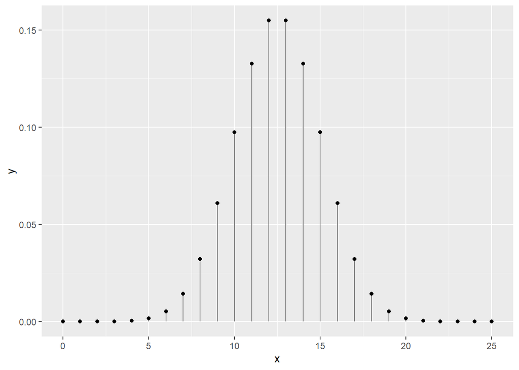

```r
ggplot(data = tibble(x, y), mapping = aes(x, y)) +
  geom_segment(aes(x = x, xend = x, y = 0, yend = y), color = "grey50") +
  geom_point()
```

La distribution la plus simple est probablement la distribution uniforme. On utilise rarement la distribution uniforme en biostatistiques, sinon pour décrire des a priori vagues pour l’analyse bayésienne.

Les distributions de mesures exclusivement positives (comme le poids ou la taille) sont parfois avantageusement approximées par une loi log-normale, qui est une loi normale sur le logarithme des valeurs: la moyenne d’une loi log-normale est la moyenne géométrique.

```r
increment <- 0.01
x <- seq(-10, 10, by = increment)
y1 <- dnorm(x, mean = 0, sd = 1)
y2 <- dnorm(x, mean = 0, sd = 2)
y3 <- dnorm(x, mean = 0, sd = 3)

print(paste('La somme des probabilités est de', sum(y3 * increment)))
```

```
## [1] "La somme des probabilités est de 0.999147010743368"
```

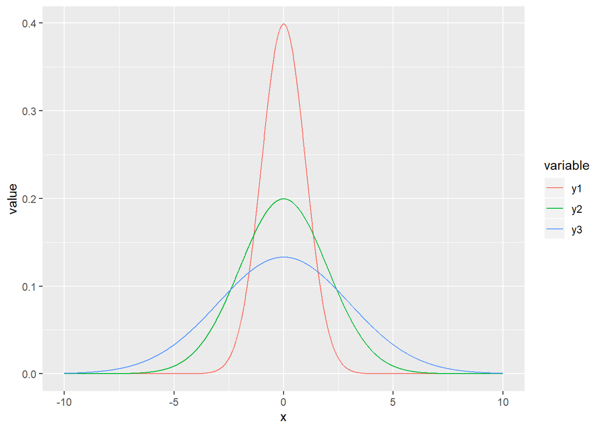

```r
gg_norm <- data.frame(x, y1, y2, y3) %>% gather(variable, value, -x)

ggplot(data = gg_norm, mapping = aes(x = x, y = value)) +
  geom_line(aes(colour = variable))
```

Quelle est la probabilité d’obtenir le nombre 0 chez une observation continue distribuée normalement dont la moyenne est 0 et l’écart-type est de 1? Réponse: 0. La loi normale étant une distribution continue, les probabilités non-nulles ne peuvent être calculés que sur des intervalles. Par exemple, la probabilité de retrouver une valeur dans l’intervalle entre -1 et 2 est calculée en soustrayant la probabilité cumulée à -1 de la probabilité cumulée à 2.

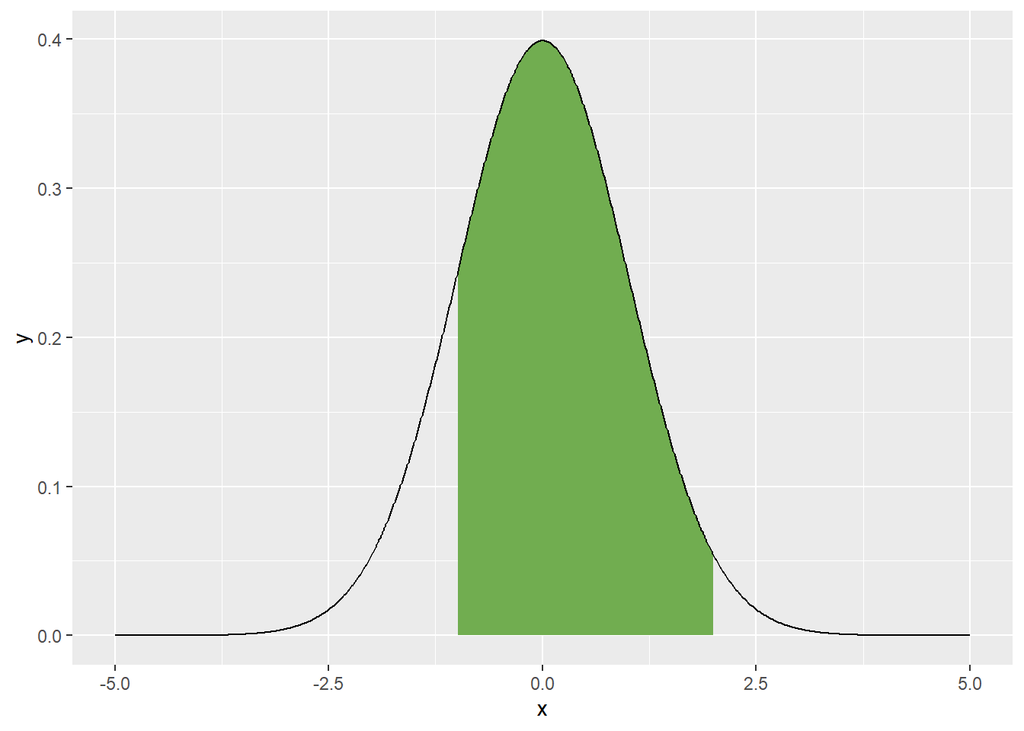

```r
increment <- 0.01
x <- seq(-5, 5, by = increment)
y <- dnorm(x, mean = 0, sd = 1)

prob_between <- c(-1, 2)

gg_norm <- data.frame(x, y)
gg_auc <- gg_norm %>%
  filter(x > prob_between[1], x < prob_between[2]) %>%
  #rbind() utilisé pour bien fermer le polygon dans ggplot
  rbind(c(prob_between[2], 0)) %>%
  rbind(c(prob_between[1], 0))

ggplot(data.frame(x, y), aes(x, y)) +
  geom_polygon(data = gg_auc, fill = '#71ad50') + # #71ad50 est un code de couleur format hexadécimal
  geom_line()
```

```r
# La fonction pnorm calcule la probabilité d'une valeur
prob_norm_between <- pnorm(q = prob_between[2], mean = 0, sd = 1) - pnorm(q = prob_between[1], mean = 0, sd = 1)
print(paste("La probabilité d'obtenir un nombre entre",
            prob_between[1], "et",
            prob_between[2], "est d'environ",
            round(prob_norm_between, 2) * 100, "%"))
```

```
## [1] "La probabilité d'obtenir un nombre entre -1 et 2 est d'environ 82 %"
```

La figure ci-dessous montre l’aire sous la courbe répresentant 95% de la population

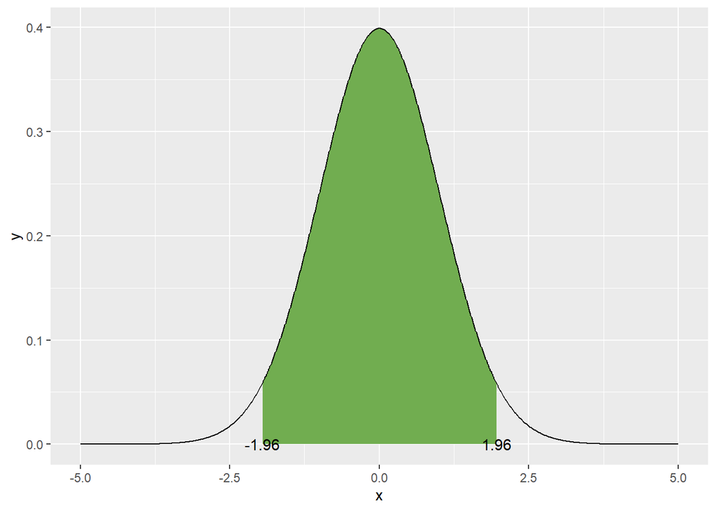

```r
increment <- 0.01
x <- seq(-5, 5, by = increment)
y <- dnorm(x, mean = 0, sd = 1)

alpha <- 0.05
prob_between <- c(qnorm(p = alpha/2, mean = 0, sd = 1),
                  qnorm(p = 1 - alpha/2, mean = 0, sd = 1))

gg_norm <- data.frame(x, y)
gg_auc <- gg_norm %>%
  filter(x > prob_between[1], x < prob_between[2]) %>%
  rbind(c(prob_between[2], 0)) %>%
  rbind(c(prob_between[1], 0))

ggplot(data = data.frame(x, y), mapping = aes(x, y)) +
  geom_polygon(data = gg_auc, fill = '#71ad50') + # #71ad50 est un code de couleur format hexadécimal
  geom_line() +
  geom_text(data = data.frame(x = prob_between,
                              y = c(0, 0),
                              labels = round(prob_between, 2)),
            mapping = aes(label = labels))
```

En effet, la moyenne suit aussi une distribution normale, dont la tendance centrale est la moyenne de la distribution, et dont **l’écart-type est noté erreur standard**.On calcule cette erreur en divisant **la variance par le nombre d’observations, ou en divisant l’écart-type par la racine carrée du nombre d’observations**.

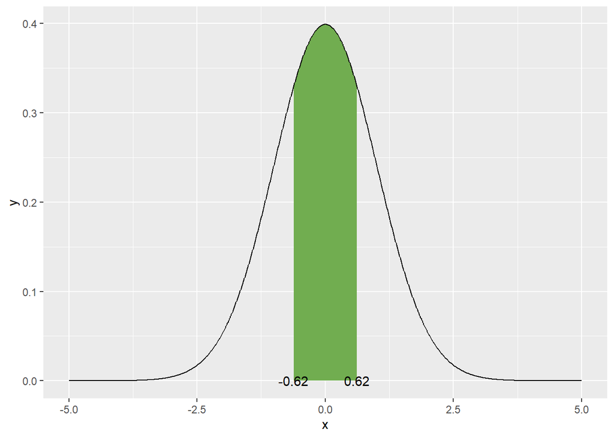

```r
increment <- 0.01
x <- seq(-5, 5, by = increment)
y <- dnorm(x, mean = 0, sd = 1)

alpha <- 0.05
prob_between <- c(qnorm(p = alpha/2, mean = 0, sd = 1) / sqrt(10),
                  qnorm(p = 1 - alpha/2, mean = 0, sd = 1) / sqrt(10))

gg_norm <- data.frame(x, y)
gg_auc <- gg_norm %>%
  filter(x > prob_between[1], x < prob_between[2]) %>%
  rbind(c(prob_between[2], 0)) %>%
  rbind(c(prob_between[1], 0))

ggplot(data = data.frame(x, y), mapping = aes(x, y)) +
  geom_polygon(data = gg_auc, fill = '#71ad50') + # #71ad50 est un code de couleur format hexadécimal
  geom_line() +
  geom_text(data = data.frame(x = prob_between,
                              y = c(0, 0),
                              labels = round(prob_between, 2)),
            mapping = aes(label = labels))
```

**Statistiques descriptives**

```r
data("iris")

#Résumé des statistiques des variables contenues dans le data.frame iris
summary(iris)
```

```
##   Sepal.Length    Sepal.Width     Petal.Length    Petal.Width
##  Min.   :4.300   Min.   :2.000   Min.   :1.000   Min.   :0.100
##  1st Qu.:5.100   1st Qu.:2.800   1st Qu.:1.600   1st Qu.:0.300
##  Median :5.800   Median :3.000   Median :4.350   Median :1.300
##  Mean   :5.843   Mean   :3.057   Mean   :3.758   Mean   :1.199
##  3rd Qu.:6.400   3rd Qu.:3.300   3rd Qu.:5.100   3rd Qu.:1.800
##  Max.   :7.900   Max.   :4.400   Max.   :6.900   Max.   :2.500
##        Species
##  setosa    :50
##  versicolor:50
##  virginica :50
##
##
##
```

```r
# Moyenne des différentes variables sélon le type d'espèce
iris %>%
  group_by(Species) %>%
  summarise_all(mean)
```

```
## # A tibble: 3 x 5
##   Species    Sepal.Length Sepal.Width Petal.Length Petal.Width
##   <fct>             <dbl>       <dbl>        <dbl>       <dbl>
## 1 setosa             5.01        3.43         1.46       0.246
## 2 versicolor         5.94        2.77         4.26       1.33
## 3 virginica          6.59        2.97         5.55       2.03
```

```r
# Quartiles 25, 50 et 75 des difféerentes variables sélon l'espèce
iris %>%
  group_by(Species) %>%
  summarise_all(list(q25 = ~ quantile(., probs = 0.25),
                     q50 = ~ quantile(., probs = 0.50),
                     q75 = ~ quantile(., probs = 0.75)))
```

```
## # A tibble: 3 x 13
##   Species Sepal.Length_q25 Sepal.Width_q25 Petal.Length_q25 Petal.Width_q25
##   <fct>              <dbl>           <dbl>            <dbl>           <dbl>
## 1 setosa              4.8             3.2               1.4             0.2
## 2 versic~             5.6             2.52              4               1.2
## 3 virgin~             6.22            2.8               5.1             1.8
## # ... with 8 more variables: Sepal.Length_q50 <dbl>, Sepal.Width_q50 <dbl>,
## #   Petal.Length_q50 <dbl>, Petal.Width_q50 <dbl>, Sepal.Length_q75 <dbl>,
## #   Sepal.Width_q75 <dbl>, Petal.Length_q75 <dbl>, Petal.Width_q75 <dbl>
```

```r
# Fonction quantile() pour calculer les quartiles
quantile(iris$Sepal.Length[iris$Species == 'setosa'])
```

```
##   0%  25%  50%  75% 100%
##  4.3  4.8  5.0  5.2  5.8
```

```r
# table() décompte par catégorie. prop.table() obtient les proportions
tableau_croise <- table(iris$Species,
                        cut(iris$Sepal.Length, breaks = quantile(iris$Sepal.Length)))

prop.table(tableau_croise)
```

```
##
##                (4.3,5.1]   (5.1,5.8]   (5.8,6.4]   (6.4,7.9]
##   setosa     0.234899329 0.093959732 0.000000000 0.000000000
##   versicolor 0.026845638 0.134228188 0.114093960 0.060402685
##   virginica  0.006711409 0.033557047 0.120805369 0.174496644
```

**Test d’hypothèses**

Par convention, l’hypothèse nulle (écrite $H_{0}$) est l’hypothèse qu’il n’y ait pas d’effet (c’est l’hypothèse de l’avocat du diable 😈) à l’échelle de la population (et non pas à l’échelle de l’échantillon). À l’inverse, l’hypothèse alternative (écrite $H_{1}$) est l’hypothèse qu’il y ait un effet à l’échelle de la population.

*Test de t à un seul échantillon*

L’erreur standard sur la moyenne $ESM = \frac{s}{\sqrt{n}}$

```r
set.seed(33746)

# création d'une population avec distribution normale n = 20, moyenne = 16 et sd = 4
x <- rnorm(20, 16, 4)

level <-  0.95
alpha <- 1-level

x_bar <- mean(x)
s <- sd(x)
n <- length(x)

error <- qnorm(1 - alpha/2) * s / sqrt(n)
error
```

```
## [1] 1.483253
```

```r
# Intervalle de confiance
c(x_bar - error, x_bar + error)
```

```
## [1] 14.35630 17.32281
```

Si la moyenne de la population est de 16, un nombre qui se situe dans l’intervalle de confiance on accepte l’hypothèse nulle au seuil 0.05. Si le nombre d’échantillon est réduit (généralement < 30), on passera plutôt par une **distribution de t**, avec $n-1$ degrés de liberté.

```r
error <- qt(1 - alpha/2, n-1) * s / sqrt(n)
c(x_bar - error, x_bar + error)
```

```
## [1] 14.25561 17.42351
```

```r
#test de t pour vérifier si les données proviennent d'une population dont la moyenne est 18
t.test(x, mu = 18)
```

```
##
##  One Sample t-test
##
## data:  x
## t = -2.8548, df = 19, p-value = 0.01014
## alternative hypothesis: true mean is not equal to 18
## 95 percent confidence interval:
##  14.25561 17.42351
## sample estimates:
## mean of x
##  15.83956
```

En apliquant le *test de t* on constate que l’hypothèse altyernative est vraie car $16 \neq 18$.

**Test de Wicolson**

Contrairement au test t, le test de Wicolson ne demand pas des suppositions sur la distribution, car ce test est non-paramétrique basé sur le tri des valeurs.

```r
# La valeur V correspond la somme des rangs positifs

wilcox.test(x, mu = 18)
```

```
##
##  Wilcoxon signed rank test
##
## data:  x
## V = 39, p-value = 0.01208
## alternative hypothesis: true location is not equal to 18
```

*Test de t à deux échantillons*

Deux séries de données $x_{1}$ et $x_{2}$ issus de distribution normale, donc, on teste l’hypothèse nulle $\mu_{1}$ et $\mu_{2}$. Ainsi, t est calculée comme :

$$t = \frac{\tilde{x_{1}}-\tilde{x_{1}}}{ESDM}$$
L’ESDM est l’erreur standard de la différence des moyennes

$$ESDM = \sqrt{ESM_{1}^{2} + ESM_{2}^{2}}$$

Exemple avec iris et la longueur des pétales

```r
iris_pl <- iris %>%
    filter(Species != "setosa") %>%
    select(Species, Petal.Length)
sample_n(iris_pl, 5)
```

```
##      Species Petal.Length
## 1  virginica          5.2
## 2  virginica          5.8
## 3  virginica          5.1
## 4 versicolor          4.0
## 5 versicolor          4.2
```

```r
# La variable de sortie est Petal.Length qui varie en foction du groupe Species (Variable d'entrée)
t.test(formula = Petal.Length ~ Species,
       data = iris_pl, var.equal = FALSE)
```

```
##
##  Welch Two Sample t-test
##
## data:  Petal.Length by Species
## t = -12.604, df = 95.57, p-value < 2.2e-16
## alternative hypothesis: true difference in means is not equal to 0
## 95 percent confidence interval:
##  -1.49549 -1.08851
## sample estimates:
## mean in group versicolor  mean in group virginica
##                    4.260                    5.552
```

```r
tt_pl <- t.test(formula = Petal.Length ~ Species,
                data = iris_pl, var.equal = FALSE)
summary(tt_pl)
```

```
##             Length Class  Mode
## statistic   1      -none- numeric
## parameter   1      -none- numeric
## p.value     1      -none- numeric
## conf.int    2      -none- numeric
## estimate    2      -none- numeric
## null.value  1      -none- numeric
## alternative 1      -none- character
## method      1      -none- character
## data.name   1      -none- character
```

```r
str(tt_pl)
```

```
## List of 9
##  $ statistic  : Named num -12.6
##   ..- attr(*, "names")= chr "t"
##  $ parameter  : Named num 95.6
##   ..- attr(*, "names")= chr "df"
##  $ p.value    : num 4.9e-22
##  $ conf.int   : num [1:2] -1.5 -1.09
##   ..- attr(*, "conf.level")= num 0.95
##  $ estimate   : Named num [1:2] 4.26 5.55
##   ..- attr(*, "names")= chr [1:2] "mean in group versicolor" "mean in group virginica"
##  $ null.value : Named num 0
##   ..- attr(*, "names")= chr "difference in means"
##  $ alternative: chr "two.sided"
##  $ method     : chr "Welch Two Sample t-test"
##  $ data.name  : chr "Petal.Length by Species"
##  - attr(*, "class")= chr "htest"
```

```r
# Comparaison des variances avec le test de F (Fisher)
var.test(formula = Petal.Length ~ Species,
         data = iris_pl)
```

```
##
##  F test to compare two variances
##
## data:  Petal.Length by Species
## F = 0.72497, num df = 49, denom df = 49, p-value = 0.2637
## alternative hypothesis: true ratio of variances is not equal to 1
## 95 percent confidence interval:
##  0.411402 1.277530
## sample estimates:
## ratio of variances
##          0.7249678
```

```r
# Test de Wilcoxon à deux échantillons, même formule que pour test t

wilcox.test(formula = Petal.Length ~ Species,
       data = iris_pl, var.equal = TRUE)
```

```
##
##  Wilcoxon rank sum test with continuity correction
##
## data:  Petal.Length by Species
## W = 44.5, p-value < 2.2e-16
## alternative hypothesis: true location shift is not equal to 0
```

*Les test pairés*

Utilisés lorsque deux échantollons proviennent d’une même unité expérimentale, il s’agit en fait de tests sur la différence entre deux observations

```r
set.seed(2555)

n <- 20
avant <- rnorm(n, 16, 4)
apres <- rnorm(n, 18, 3)

# Par default paired est FALSE, il faut le mettre comme TRUE pour fair le test pairé
t.test(avant, apres, paired = TRUE)
```

```
##
##  Paired t-test
##
## data:  avant and apres
## t = -1.5168, df = 19, p-value = 0.1458
## alternative hypothesis: true difference in means is not equal to 0
## 95 percent confidence interval:
##  -4.5804586  0.7311427
## sample estimates:
## mean of the differences
##               -1.924658
```

```r
wilcox.test(avant, apres, paired = TRUE)
```

```
##
##  Wilcoxon signed rank test
##
## data:  avant and apres
## V = 59, p-value = 0.08969
## alternative hypothesis: true location shift is not equal to 0
```

**L’analyse de variance**

L’analyse de variance consiste à comparer des moyennes de plusieurs groupe distribués normalement et de même variance.

```r
pl_aov <- aov(Petal.Length ~ Species, iris)
summary(pl_aov)
```

```
##              Df Sum Sq Mean Sq F value Pr(>F)
## Species       2  437.1  218.55    1180 <2e-16 ***
## Residuals   147   27.2    0.19
## ---
## Signif. codes:  0 '***' 0.001 '**' 0.01 '*' 0.05 '.' 0.1 ' ' 1
```

**Les modèles statistiques**

La modélisation statistique consiste à lier de manière explicite des variables de sortie $y$ (ou variables-réponse ou variables dépendantes) à des variables explicatives $x$ (ou variables prédictives / indépendantes / covariables).

*Modèles prédictifs* conçues pour prédire de manière fiable une ou plusieurs variables-réponse à partir des informations contenues dans les variables qui sont, dans ce cas, prédictives.

Lorsque l’on désire tester des hypothèses pour évaluer quelles variables expliquent la réponse, on parlera de *modélisation (et de variables) explicatives*.

Les *Variables fixes* sont les variables testées lors de l’expérience : dose du traitement, espèce, météo.

Les *Variables aléatoires* sont les sources de variation qui génèrent du bruit dans le modèle : les unités expérimentales ou le temps lors de mesures répétées.

*Modèles fixes* juste effets fixes

*Modèles mixtes* ont des variables aléatoires et fixes.

- *Modèles à effets fixes*

En particulier, le test de t est régression linéaire univariée (à une seule variable explicative) dont la variable explicative comprend deux catégories. De même, l’anova est une régression linéaire univariée dont la variable explicative comprend plusieurs catégories.

Modèle lineaire univarié aura la forme $y = \beta_{0} + \beta_{1}x + \epsilon$, où $\epsilon$ est l’erreur.

- *Modèle linéaire univarié avec variable continue*

```r
library("agridat")
data("lasrosas.corn")
sample_n(lasrosas.corn, 10)
```

```
##    year       lat      long  yield nitro topo     bv rep nf
## 1  2001 -33.05109 -63.84451  94.15  50.6    E 173.54  R1 N2
## 2  2001 -33.04908 -63.84830  90.19  99.8    W  91.74  R3 N4
## 3  1999 -33.05165 -63.84257  73.60   0.0   LO 173.23  R2 N0
## 4  2001 -33.05175 -63.84320 108.95  75.4   LO 163.38  R1 N3
## 5  2001 -33.05111 -63.84444 101.67  50.6    E 174.00  R1 N2
## 6  2001 -33.05139 -63.84244  98.74  50.6   LO 167.86  R2 N2
## 7  1999 -33.05121 -63.84224  81.70  29.0   LO 166.59  R3 N1
## 8  2001 -33.05088 -63.84491  50.59  39.0    E 179.56  R1 N1
## 9  1999 -33.05103 -63.84404  61.44   0.0    E 166.84  R3 N0
## 10 2001 -33.05052 -63.84613  46.06  50.6   HT 178.54  R1 N2
```

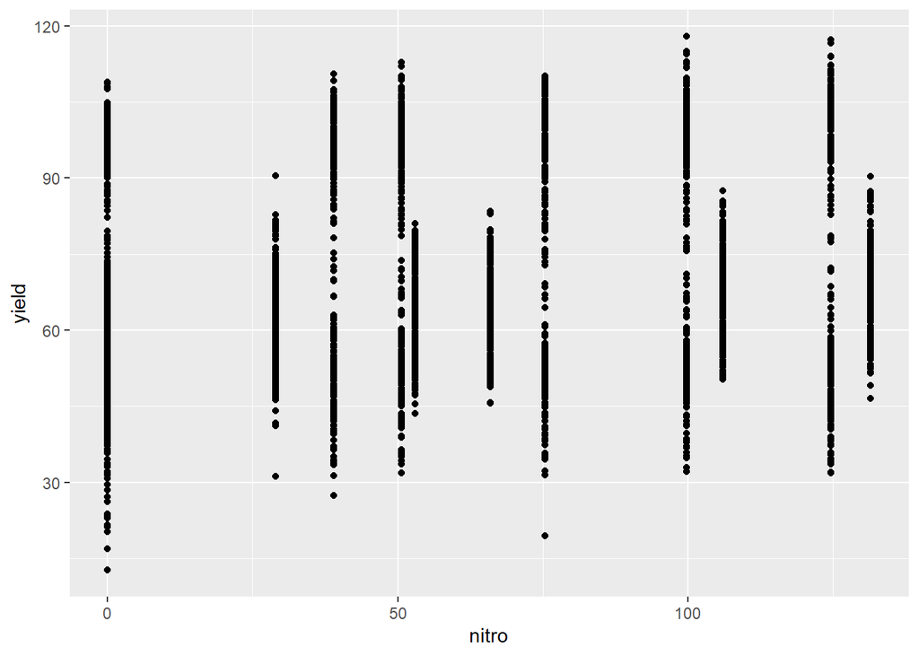

```r
# nitro comme variable explicative ou indépendante et yield comme variable dépendante
ggplot(data = lasrosas.corn, mapping = aes(x = nitro, y = yield)) +
    geom_point()
```

```r
modlin_1 <- lm(yield ~ nitro, data = lasrosas.corn)
summary(modlin_1)
```

```
##
## Call:
## lm(formula = yield ~ nitro, data = lasrosas.corn)
##
## Residuals:
##     Min      1Q  Median      3Q     Max
## -53.183 -15.341  -3.079  13.725  45.897
##
## Coefficients:
##              Estimate Std. Error t value Pr(>|t|)
## (Intercept) 65.843213   0.608573 108.193  < 2e-16 ***
## nitro        0.061717   0.007868   7.845 5.75e-15 ***
## ---
## Signif. codes:  0 '***' 0.001 '**' 0.01 '*' 0.05 '.' 0.1 ' ' 1
##
## Residual standard error: 19.66 on 3441 degrees of freedom
## Multiple R-squared:  0.01757,    Adjusted R-squared:  0.01728
## F-statistic: 61.54 on 1 and 3441 DF,  p-value: 5.754e-15
```

Des résultats obtenus la médiane des résidus devrait s’approcher de la moyenne des résidus (toujours 0). Bien que le -3.079 peut sembler important, il faut prendre en considération de l’échelle de y. La distribution des résidus mérite d’être davantage investiguée.

```r
# Calcul des intervalles de confiance
confint(modlin_1, level = 0.95)
```

```
##                   2.5 %      97.5 %
## (Intercept) 64.65001137 67.03641474
## nitro        0.04629164  0.07714271
```

```r
# Dans le résultat de la fonction coefficients() on obtient l'intercept et la pente
coefficients(modlin_1)
```

```
## (Intercept)       nitro
## 65.84321305  0.06171718
```

```r
# Éxecution du modèle sur les données qui ont servi à le générer
predict(modlin_1)[1:5]
```

```
##        1        2        3        4        5
## 73.95902 73.95902 73.95902 73.95902 73.95902
```

```r
#Ou sur des données externes
nouvelles_donnees <- data.frame(nitro = seq(from = 0, to = 100, by = 5))
predict(modlin_1, newdata = nouvelles_donnees)[1:5]
```

```
##        1        2        3        4        5
## 65.84321 66.15180 66.46038 66.76897 67.07756
```

- *Analyse des résidus*

Vecteur $\epsilon$ qui est un décalage entre le données et le modèle. Les résidus sont le résultat de $\epsilon = y - \hat{y}$ ou d’utiliser la fonction `residuals()`.

```r
res_df <- data.frame(nitro = lasrosas.corn$nitro,
                     residus_lm = residuals(modlin_1),
                     residus_calcul = lasrosas.corn$yield - predict(modlin_1))
sample_n(res_df, 10)
```

```
##    nitro  residus_lm residus_calcul
## 1   66.0 -18.5165468    -18.5165468
## 2   66.0  -7.5965468     -7.5965468
## 3   53.0  -2.6342234     -2.6342234
## 4   39.0  26.5998170     26.5998170
## 5   99.8 -20.7825873    -20.7825873
## 6    0.0  -0.1132131     -0.1132131
## 7    0.0 -16.9032131    -16.9032131
## 8  131.5   2.6109781      2.6109781
## 9   39.0  36.5598170     36.5598170
## 10  66.0 -20.2665468    -20.2665468
```

Dans une bonne régression linéaire, on ne retrouvera pas de structure identifiable dans les résidus, c’est-à-dire que les résidus sont bien distribués de part et d’autre du modèle de régression.

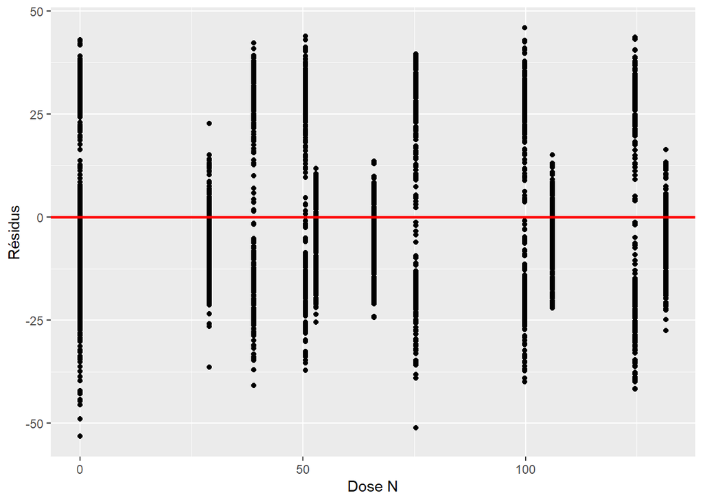

```r
ggplot(res_df, aes(x = nitro, y = residus_lm)) +
  geom_point() +
  labs(x = "Dose N", y = "Résidus") +
  geom_hline(yintercept = 0, col = "red", size = 1)
```

On pourra aussi inspecter les résidus avec un graphique de leur distribution. L’histogramme devrait présenter une distribution normale. Les tests de normalité comme le test de Shapiro-Wilk peuvent aider, mais ils sont généralement très sévères.

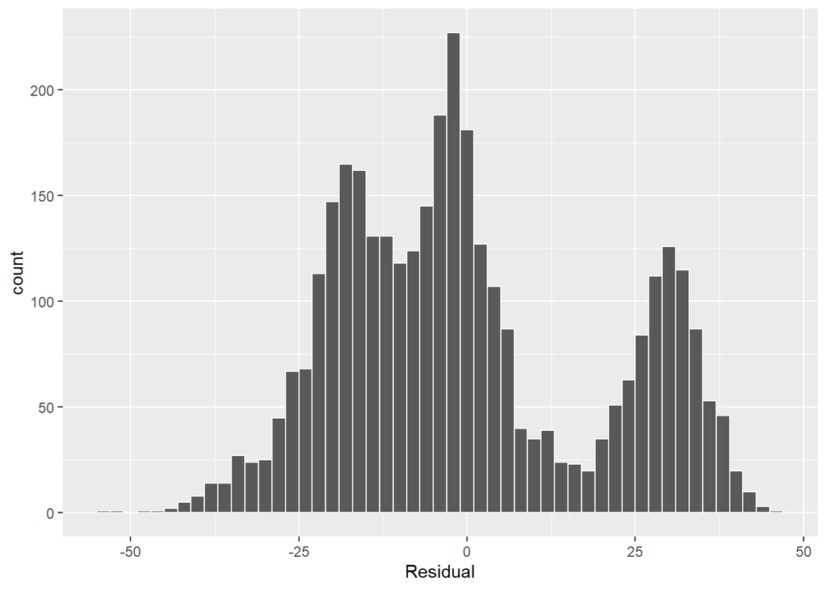

```r
ggplot(res_df, aes(x = residus_lm)) +
  geom_histogram(binwidth = 2, color = "white") +
  labs(x = "Residual")
```

```r
#Test de Shapito-Wilk
shapiro.test(res_df$residus_lm)
```

```
##
##  Shapiro-Wilk normality test
##
## data:  res_df$residus_lm
## W = 0.94868, p-value < 2.2e-16
```

L’hypothèse nulle que la distribution est normale est rejetée au seuil 0.05. Dans notre cas, il est évident que la sévérité du test n’est pas en cause, car les résidus semble générer trois ensembles. **Ceci indique que les variables explicatives sont insuffisantes pour expliquer la variabilité de la variable-réponse**.

## **Régression multiple**

Lorsque l’on combine plusieurs variables explicatives, on crée un modèle de régression multivariée ou multiple :

$$y = X\beta + \epsilon$$

Où, $X$ est la matrice du modèle à $n$ observations et $p$ variables, $\beta$ est la matrice des $p$ coefficients, $\beta_{0}$ est l’intercept qui multiplie la première colonne de la matrice $X$ et $\epsilon$ est l’erreur de chaque observation.

*Modèles linéaires univariés avec variable catégorielle nominale*

Une variable catégorielle nominale (non ordonnée) utilisée à elle seule dans un modèle comme variable explicative, est un cas particulier de régression multiple.

```r
data <- data.frame(cultivar = c('Superior', 'Superior', 'Superior', 'Russet', 'Kenebec', 'Russet'))
model.matrix(~cultivar, data)
```

```
##   (Intercept) cultivarRusset cultivarSuperior
## 1           1              0                1
## 2           1              0                1
## 3           1              0                1
## 4           1              1                0
## 5           1              0                0
## 6           1              1                0
## attr(,"assign")
## [1] 0 1 1
## attr(,"contrasts")
## attr(,"contrasts")$cultivar
## [1] "contr.treatment"
```

L’information contenue dans un nombre $C$ de catégorie peut être encodée dans un nombre $C - 1$ de colonnes. C’est pourquoi, dans une analyse statistique, on désignera une catégorie comme une référence, que l’on détecte lorsque toutes les autres catégories sont encodées avec des $0$ : cette référence sera incluse dans *l’intercept*. Dans l’exemple ci-dessus l’intercept a été le cultivar *kenebec*. On peut modifier la référence avec la fonction `relevel()`.

```r
levels(lasrosas.corn$topo)
```

```
## [1] "E"  "HT" "LO" "W"
```

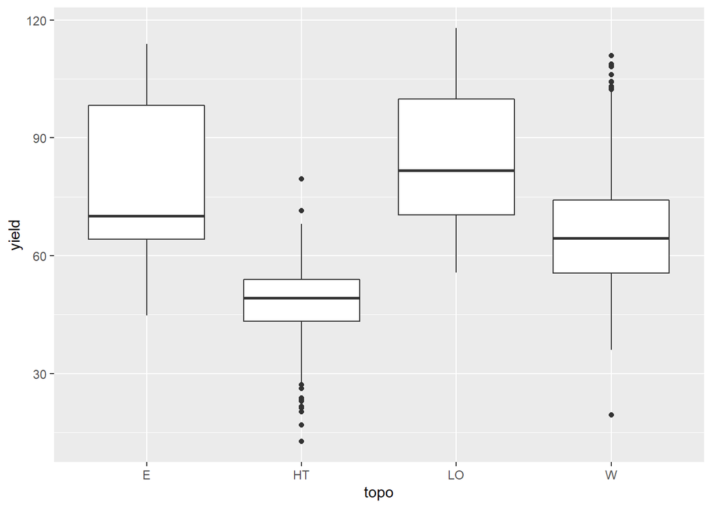

```r
ggplot(lasrosas.corn, aes(x = topo, y = yield)) +
    geom_boxplot()
```

```r
# La fonction model.matrix() sert à générer l'encodage catégoriel
# Dans ce cas l'intercept est le niveau E
model.matrix(~ topo, data = lasrosas.corn) %>%
    tbl_df() %>% # tbl_df pour transformer la matrice en tableau
    sample_n(10)
```

```
## # A tibble: 10 x 4
##    `(Intercept)` topoHT topoLO topoW
##            <dbl>  <dbl>  <dbl> <dbl>
##  1             1      0      1     0
##  2             1      1      0     0
##  3             1      0      1     0
##  4             1      1      0     0
##  5             1      0      0     1
##  6             1      0      0     1
##  7             1      0      0     1
##  8             1      1      0     0
##  9             1      0      1     0
## 10             1      0      0     1
```

Cette matrice de modèle utilisée pour la régression donnera un intercept, qui indiquera l’effet de la catégorie de référence, puis les différences entre les catégories subséquentes et la catégorie de référence.

```r
modlin_4 <- lm(yield ~ topo, data = lasrosas.corn)
summary(modlin_4)
```

```
##
## Call:
## lm(formula = yield ~ topo, data = lasrosas.corn)
##
## Residuals:
##     Min      1Q  Median      3Q     Max
## -47.371 -11.933  -1.593  11.080  44.119
##
## Coefficients:
##             Estimate Std. Error t value Pr(>|t|)
## (Intercept)  78.6653     0.5399 145.707   <2e-16 ***
## topoHT      -30.0526     0.7500 -40.069   <2e-16 ***
## topoLO        6.2832     0.7293   8.615   <2e-16 ***
## topoW       -11.8841     0.7039 -16.883   <2e-16 ***
## ---
## Signif. codes:  0 '***' 0.001 '**' 0.01 '*' 0.05 '.' 0.1 ' ' 1
##
## Residual standard error: 14.59 on 3439 degrees of freedom
## Multiple R-squared:  0.4596, Adjusted R-squared:  0.4591
## F-statistic:   975 on 3 and 3439 DF,  p-value: < 2.2e-16
```

```r
res_df2 <- data.frame(topo = lasrosas.corn$topo,
                     residus_lm = residuals(modlin_4),
                     residus_calcul = lasrosas.corn$yield - predict(modlin_4))
sample_n(res_df2, 10)
```

```
##    topo residus_lm residus_calcul
## 1     W -15.601179     -15.601179
## 2     W   1.848821       1.848821
## 3     W -13.861179     -13.861179
## 4    HT   7.197287       7.197287
## 5     E  14.934671      14.934671
## 6    LO  10.371480      10.371480
## 7     E  23.414671      23.414671
## 8    HT  -8.762713      -8.762713
## 9     W -12.381179     -12.381179
## 10   HT   4.747287       4.747287
```

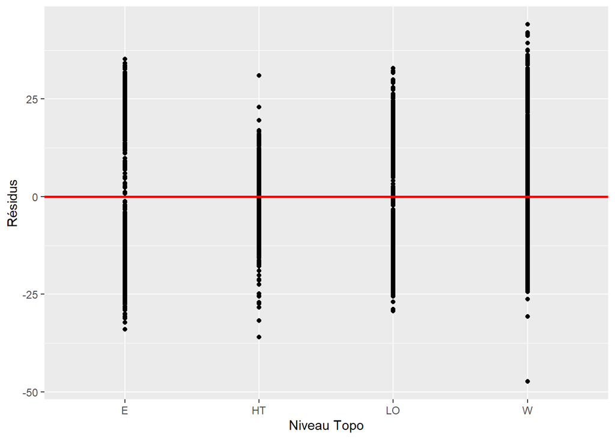

```r
ggplot(res_df2, aes(x = topo, y = residus_lm)) +
  geom_point() +
  labs(x = "Niveau Topo", y = "Résidus") +
  geom_hline(yintercept = 0, col = "red", size = 1)
```

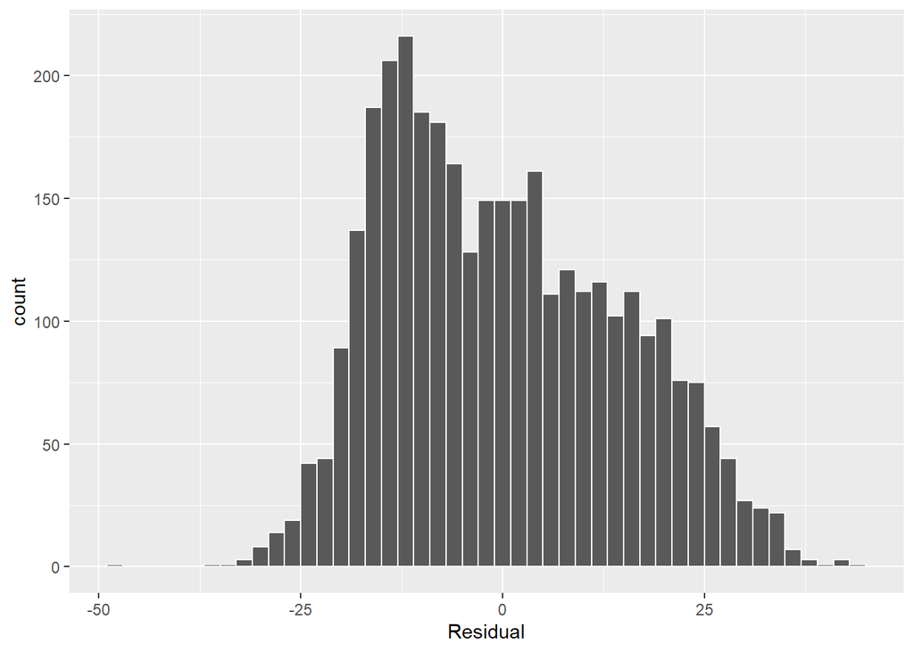

```r
#Histograme des résidus régression variable catégorielle nominale
ggplot(res_df2, aes(x = residus_lm)) +
  geom_histogram(binwidth = 2, color = "white") +
  labs(x = "Residual")
```

```r
#Test de Shapito-Wilk
shapiro.test(res_df2$residus_lm)
```

```
##
##  Shapiro-Wilk normality test
##
## data:  res_df2$residus_lm
## W = 0.97394, p-value < 2.2e-16
```

### **Régresion multiple à plusieurs variables**

```r
head(lasrosas.corn)
```

```
##   year       lat      long yield nitro topo     bv rep nf
## 1 1999 -33.05113 -63.84886 72.14 131.5    W 162.60  R1 N5
## 2 1999 -33.05115 -63.84879 73.79 131.5    W 170.49  R1 N5
## 3 1999 -33.05116 -63.84872 77.25 131.5    W 168.39  R1 N5
## 4 1999 -33.05117 -63.84865 76.35 131.5    W 176.68  R1 N5
## 5 1999 -33.05118 -63.84858 75.55 131.5    W 171.46  R1 N5
## 6 1999 -33.05120 -63.84851 70.24 131.5    W 170.56  R1 N5
```

```r
# lat = latitude long = longitude bv = teneur en matière organique plus bv = moins MO
modlin_5 <- lm(yield ~ lat + long + nitro + topo + bv,
               data = lasrosas.corn)
summary(modlin_5)
```

```
##
## Call:
## lm(formula = yield ~ lat + long + nitro + topo + bv, data = lasrosas.corn)
##
## Residuals:
##     Min      1Q  Median      3Q     Max
## -48.405 -11.071  -1.251  10.592  40.078
##
## Coefficients:
##               Estimate Std. Error t value Pr(>|t|)
## (Intercept)  1.946e+05  3.309e+04   5.882 4.45e-09 ***
## lat          5.541e+03  4.555e+02  12.163  < 2e-16 ***
## long         1.776e+02  4.491e+02   0.395    0.693
## nitro        6.867e-02  5.451e-03  12.597  < 2e-16 ***
## topoHT      -2.665e+01  1.087e+00 -24.520  < 2e-16 ***
## topoLO       5.565e+00  1.035e+00   5.378 8.03e-08 ***
## topoW       -1.465e+01  1.655e+00  -8.849  < 2e-16 ***
## bv          -5.089e-01  3.069e-02 -16.578  < 2e-16 ***
## ---
## Signif. codes:  0 '***' 0.001 '**' 0.01 '*' 0.05 '.' 0.1 ' ' 1
##
## Residual standard error: 13.47 on 3435 degrees of freedom
## Multiple R-squared:  0.5397, Adjusted R-squared:  0.5387
## F-statistic: 575.3 on 7 and 3435 DF,  p-value: < 2.2e-16
```

Les variables ne sont pas comparables puisque n’ont pas la même échelle

```r
lasrosas.corn_sc <- lasrosas.corn %>%
    mutate_at(c("lat", "long", "nitro", "bv"), scale)

modlin_5_sc <- lm(yield ~ lat + long + nitro + topo + bv,
               data = lasrosas.corn_sc)
summary(modlin_5_sc)
```

```
##
## Call:
## lm(formula = yield ~ lat + long + nitro + topo + bv, data = lasrosas.corn_sc)
##
## Residuals:
##     Min      1Q  Median      3Q     Max
## -48.405 -11.071  -1.251  10.592  40.078
##
## Coefficients:
##             Estimate Std. Error t value Pr(>|t|)
## (Intercept)  78.9114     0.6666 118.376  < 2e-16 ***
## lat           3.9201     0.3223  12.163  < 2e-16 ***
## long          0.3479     0.8796   0.395    0.693
## nitro         2.9252     0.2322  12.597  < 2e-16 ***
## topoHT      -26.6487     1.0868 -24.520  < 2e-16 ***
## topoLO        5.5647     1.0347   5.378 8.03e-08 ***
## topoW       -14.6487     1.6555  -8.849  < 2e-16 ***
## bv           -4.9253     0.2971 -16.578  < 2e-16 ***
## ---
## Signif. codes:  0 '***' 0.001 '**' 0.01 '*' 0.05 '.' 0.1 ' ' 1
##
## Residual standard error: 13.47 on 3435 degrees of freedom
## Multiple R-squared:  0.5397, Adjusted R-squared:  0.5387
## F-statistic: 575.3 on 7 and 3435 DF,  p-value: < 2.2e-16
```

On pourra retrouver des cas où l’effet combiné de plusieurs variables diffère de l’effet des deux variables prises séparément

```r
# Dans nitro*topo l'étoile (astérisque) sert à évaluer l'effet de l'interaction
modlin_5_sc <- lm(yield ~ nitro*topo,
               data = lasrosas.corn_sc)
summary(modlin_5_sc)
```

```
##
## Call:
## lm(formula = yield ~ nitro * topo, data = lasrosas.corn_sc)
##
## Residuals:
##     Min      1Q  Median      3Q     Max
## -47.984 -11.985  -1.388  10.339  40.636
##
## Coefficients:
##              Estimate Std. Error t value Pr(>|t|)
## (Intercept)   78.6999     0.5322 147.870  < 2e-16 ***
## nitro          1.8131     0.5351   3.388 0.000711 ***
## topoHT       -30.0052     0.7394 -40.578  < 2e-16 ***
## topoLO         6.2026     0.7190   8.627  < 2e-16 ***
## topoW        -11.9628     0.6939 -17.240  < 2e-16 ***
## nitro:topoHT   1.2553     0.7461   1.682 0.092565 .
## nitro:topoLO   0.5695     0.7186   0.792 0.428141
## nitro:topoW    0.7702     0.6944   1.109 0.267460
## ---
## Signif. codes:  0 '***' 0.001 '**' 0.01 '*' 0.05 '.' 0.1 ' ' 1
##
## Residual standard error: 14.38 on 3435 degrees of freedom
## Multiple R-squared:  0.4756, Adjusted R-squared:  0.4746
## F-statistic: 445.1 on 7 and 3435 DF,  p-value: < 2.2e-16
```

Les résultats montre des effets de l’azote et des catégories topographiques, mais il y a davantage d’incertitude sur les interactions, indiquant que l’effet statistique de l’azote est sensiblement le même indépendamment des niveaux topographiques.

**Il faut ne pas surcharger le modèle** puisque plus il y a d’interactions, plus votre modèle comprendra de variables et vos tests d’hypothèse perdront en puissance statistique.